# Capstone: Milestone Report Instructions

Joseph Boateng

2021-03-16

## Important Information

It is especially important to submit this assignment before the deadline, March 29, 11:59 PM PDT, because it must be graded by others. If you submit late, there may not be enough classmates around to review your work. This makes it difficult - and in some cases, impossible - to produce a grade. Submit on time to avoid these risks.

## Instructions

The goal of this project is just to display that you’ve gotten used to working with the data and that you are on track to create your prediction algorithm. Please submit a report on R Pubs (http://rpubs.com/) that explains your exploratory analysis and your goals for the eventual app and algorithm. This document should be concise and explain only the major features of the data you have identified and briefly summarize your plans for creating the prediction algorithm and Shiny app in a way that would be understandable to a non-data scientist manager. You should make use of tables and plots to illustrate important summaries of the data set. The motivation for this project is to: 1. Demonstrate that you’ve downloaded the data and have successfully loaded it in.2. Create a basic report of summary statistics about the data sets.3. Report any interesting findings that you amassed so far.4. Get feedback on your plans for creating a prediction algorithm and Shiny app.

##Review criteria 1. Does the link lead to an HTML page describing the exploratory analysis of the training data set? 2. Has the data scientist done basic summaries of the three files? Word counts, line counts and basic data tables? 3. Has the data scientist made basic plots, such as histograms to illustrate features of the data? 4. Was the report written in a brief, concise style, in a way that a non-data scientist manager could appreciate?

#Load and explore data

```r
#' ## Download and explore the data
#'
#' Create a data directory
if (!file.exists("data")) {
  dir.create("data")
}

#' Download the data
# url <- "https://d396qusza40orc.cloudfront.net/dsscapstone/dataset/Coursera-SwiftKey.zip"
# download(url, dest="dataset.zip", mode="wb")
# unzip ("dataset.zip", exdir = "./data")

#' English Repository Files
blogs_file   <-  "./data/final/en_US/en_US.blogs.txt"
news_file    <- "./data/final/en_US/en_US.news.txt"
twitter_file <- "./data/final/en_US/en_US.twitter.txt"

#' File Sizes (Mb)
blogs_size   <- file.size(blogs_file) / (2^20)
news_size    <- file.size(news_file) / (2^20)
twitter_size <- file.size(twitter_file) / (2^20)

#' Read the data files
blogs   <- readLines(blogs_file, skipNul = TRUE)
news    <- readLines(news_file,  skipNul = TRUE)
twitter <- readLines(twitter_file, skipNul = TRUE)

#' Number of Lines per file
blogs_lines   <- length(blogs)
news_lines    <- length(news)
twitter_lines <- length(twitter)
total_lines   <- blogs_lines + news_lines + twitter_lines

#' Distibution of characters per line, by file
blogs_nchar   <- nchar(blogs)
news_nchar    <- nchar(news)
twitter_nchar <- nchar(twitter)

#boxplot(blogs_nchar, news_nchar, twitter_nchar, log = "y",
 #       names = c("blogs", "news", "twitter"),
  #      ylab = "log(Number of Characters)", xlab = "File Name")
#title("Comparing Distributions of Chracters per Line")

#' Total characters per file
blogs_nchar_sum   <- sum(blogs_nchar)
news_nchar_sum    <- sum(news_nchar)
twitter_nchar_sum <- sum(twitter_nchar)

#' Total words per file
blogs_words <- wordcount(blogs, sep = " ")
news_words  <- wordcount(news,  sep = " ")
twitter_words <- wordcount(twitter, sep = " ")

#' Create summary of repo stats
repo_summary <- data.frame(f_names = c("blogs", "news", "twitter"),
                           f_size  = c(blogs_size, news_size, twitter_size),
                           f_lines = c(blogs_lines, news_lines, twitter_lines),
                           n_char =  c(blogs_nchar_sum, news_nchar_sum, twitter_nchar_sum),
                           n_words = c(blogs_words, news_words, twitter_words))

repo_summary <- repo_summary %>% mutate(pct_n_char = round(n_char/sum(n_char), 2))
repo_summary <- repo_summary %>% mutate(pct_lines = round(f_lines/sum(f_lines), 2))
repo_summary <- repo_summary %>% mutate(pct_words = round(n_words/sum(n_words), 2))
kable(repo_summary)
```

| f_names | f_size | f_lines | n_char | n_words | pct_n_char | pct_lines | pct_words |
| --- | --- | --- | --- | --- | --- | --- | --- |
| blogs | 200.4242 | 899288 | 208361438 | 37334131 | 0.54 | 0.27 | 0.53 |
| news | 196.2775 | 77259 | 15683765 | 2643969 | 0.04 | 0.02 | 0.04 |
| twitter | 159.3641 | 2360148 | 162385035 | 30373583 | 0.42 | 0.71 | 0.43 |

```r
saveRDS(repo_summary, "./clean_repos/repo_summary.rds")
```

#Reads all clean data from previous get n clean exercise

## Introduction

This project analyzes the [HC Corpora Dataset](https://d396qusza40orc.cloudfront.net/dsscapstone/dataset/Coursera-SwiftKey.zip) with the end goal of creating a Shiny App for predicting n-grams. This first milestone report summarizes an exploratory data analysis.

## File Summary

Three data files sourced from blogs, news, and twitter were read into R. The news file had hidden null characters preventing a full file read and these null characters required hand deletion with Notepad++ prior to file loading.

| f_names | f_size | f_lines | n_char | n_words | pct_n_char | pct_lines | pct_words |
| --- | --- | --- | --- | --- | --- | --- | --- |
| blogs | 200.4242 | 899288 | 208361438 | 37334131 | 0.54 | 0.27 | 0.53 |
| news | 196.2775 | 77259 | 15683765 | 2643969 | 0.04 | 0.02 | 0.04 |
| twitter | 159.3641 | 2360148 | 162385035 | 30373583 | 0.42 | 0.71 | 0.43 |

Processing files of this size pushed up against R’s memory limits and ran slowly. To facilitate analysis, I sampled ten percent of the lines from each file. I cleaned the sample and created n-grams. To further speed processing, I subsetted the n-grams to those that covered 90% of the sample phrases. A fully reproducible version of this data analysis is available on [Github.](https://github.com/groupejopa/JHU-Data-Science-Capstone-/blob/main/02_Task_Script.md)

## Uni-grams

The corpora are populated with many acronyms and abbreviations such as “rt” for re-tIet, “lol” for laugh out loud, “ic” for I see. Notably, I chose to leave the short hand “im” for I am and “dont” for don’t / do not as is, hence they show up as uni-grams.

### Uni-gram Wordcloud

Word distribution can be summarized with a word cloud, where word size/color represents frequency. The words, “im”, and “time” show up as most frequent followed by “people”, “dont”, “day”, and “love”. This is a popular visual method, but I prefer the relative frequency column plots shown below.

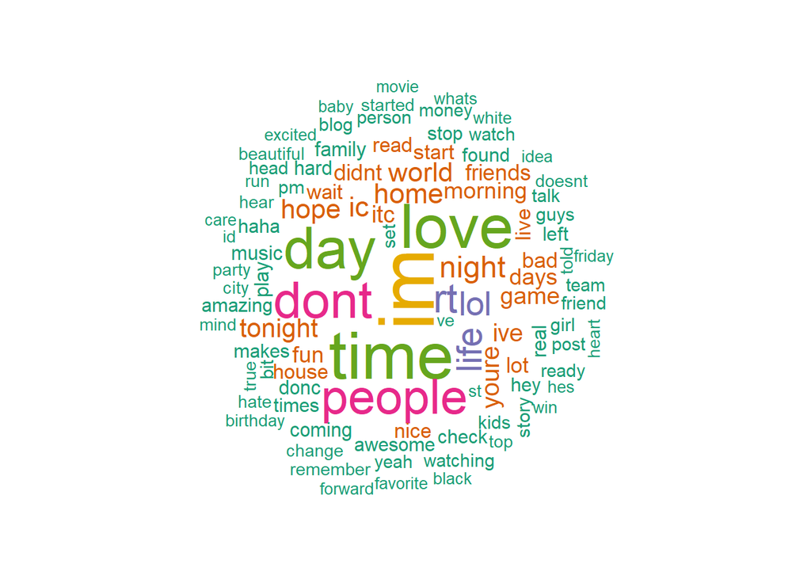

### Uni-grms, By Source

The different files - blogs, news, twitter - had different word relative frequencies. Notice that in terms of most frequent words, “rt” occurs only on twitter, “ic” and “donc” only in blogs, and “city”, “percent”, “county” only in news.

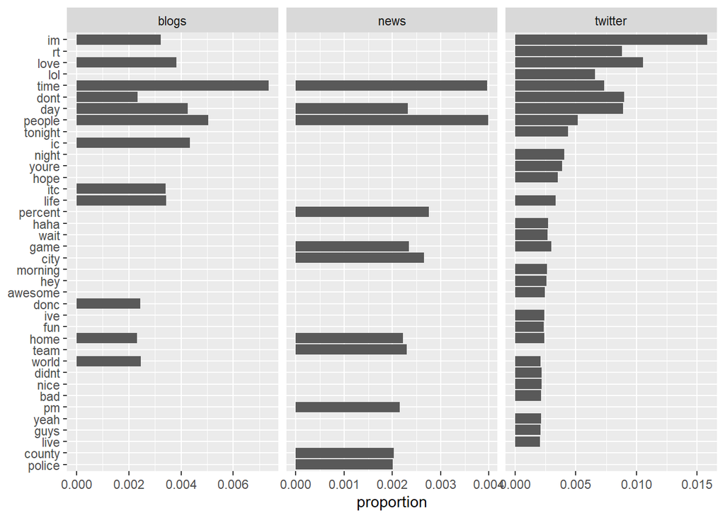

## Uni-gram Distribution

Distributions were created for each set of n-grams, based on relative frequency.

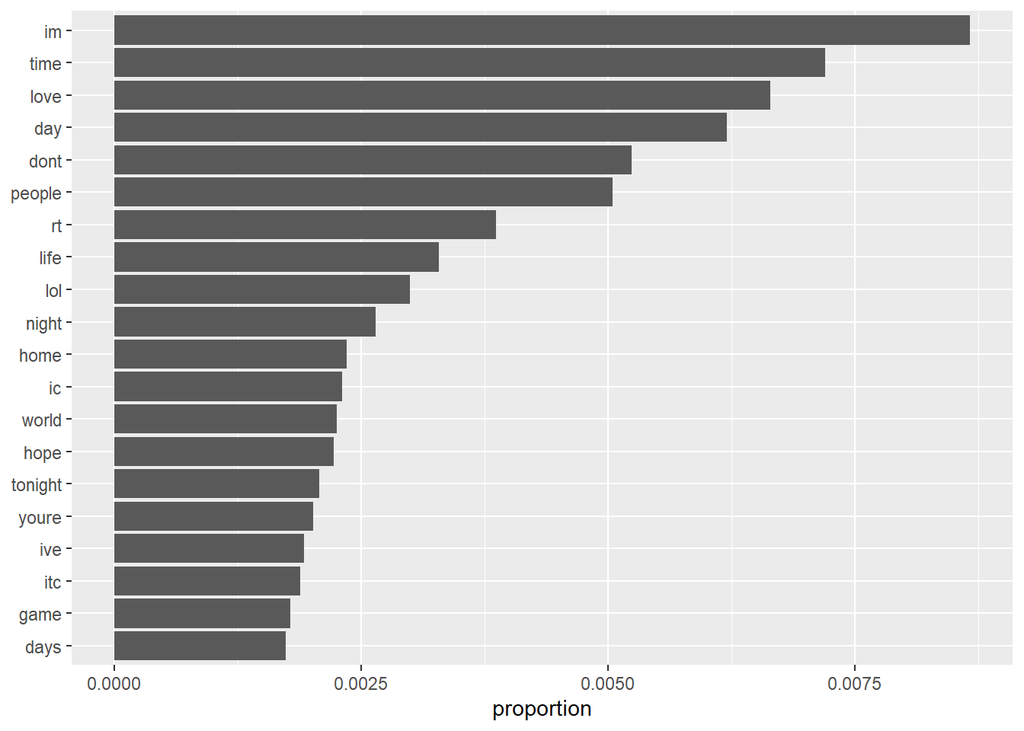

## Bi-gram Distribution

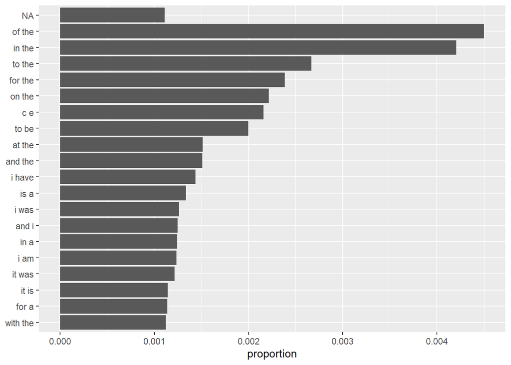

## Tri-gram Distribution

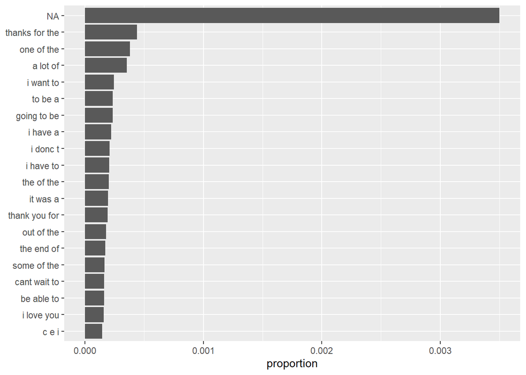

## Quad-gram Distribution

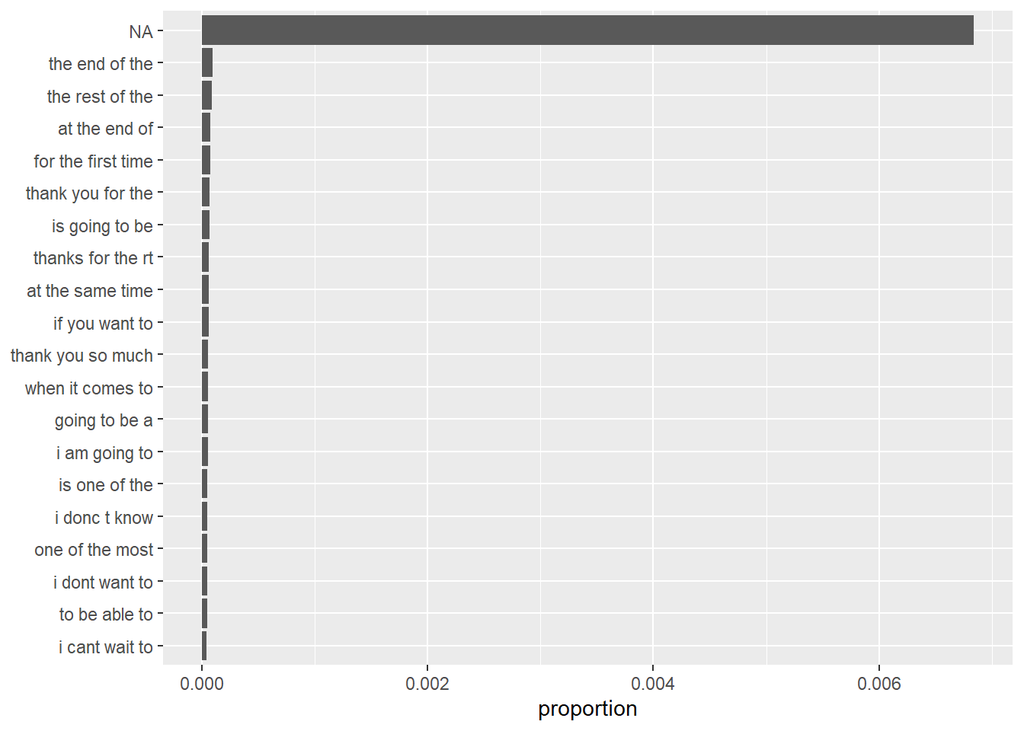

## N-gram Prediction Model

I anticipate using the n-gram tables created for bi-gram, tri-grams, and quad-grams as the basis for prediction. The user will input a word, the model will find the bi-gram with the greatest relative frequency given that word. Similarly, the tri-gram table will be used for making predictions from two word entries and so on.

| word1 | word2 | word3 | word4 | n | proportion | coverage |
| --- | --- | --- | --- | --- | --- | --- |
| NA | NA | NA | NA | 36066 | 6.84e-03 | 0.0068400 |
| the | end | of | the | 497 | 9.43e-05 | 0.0069343 |
| the | rest | of | the | 454 | 8.61e-05 | 0.0070204 |
| at | the | end | of | 405 | 7.68e-05 | 0.0070972 |
| for | the | first | time | 397 | 7.53e-05 | 0.0071725 |
| thank | you | for | the | 359 | 6.81e-05 | 0.0072406 |

Notice in the guad-gram table, that the 4-grams are separated by word and arranged by relative frequency. When the user inputs three words, the model matches those words and then finds the fourth word with the greatest relative frequency. Cases where there is no match, or where more than three words are entered, will have random completion.

# Way forward

The final deliverable in the capstone project is to build a predictive algorithm that will be deployed as a Shiny app for the user interface. The Shiny app should take as input a phrase (multiple words) in a text box input and output a prediction of the next word.

The predictive algorithm will be developed using an n-gram model with a word frequency lookup similar to that performed in the exploratory data analysis section of this report. A strategy will be built based on the knowledge gathered during the exploratory analysis. For example, as n increased for each n-gram, the frequency decreased for each of its terms. So one possible strategy may be to construct the model to first look for the unigram that would follow from the entered text. Once a full term is entered followed by a space, find the most common bigram model and so on.

Another possible strategy may be to predict the next word using the trigram model. If no matching trigram can be found, then the algorithm would check the bigram model. If still not found, use the unigram model.

The final strategy will be based on the one that increases efficiency and provides the best accuracy.